# Continuous Integration Smell Report

Wed Aug 15 11:20:47 2018

### Project: google/closure-compiler

### Slow builds

### Broken release branch

### Skip failed tests

### Aged branches

## Slow builds

↗ Uptrend:

Over the last 90 days, your build duration increased by 51.4%.

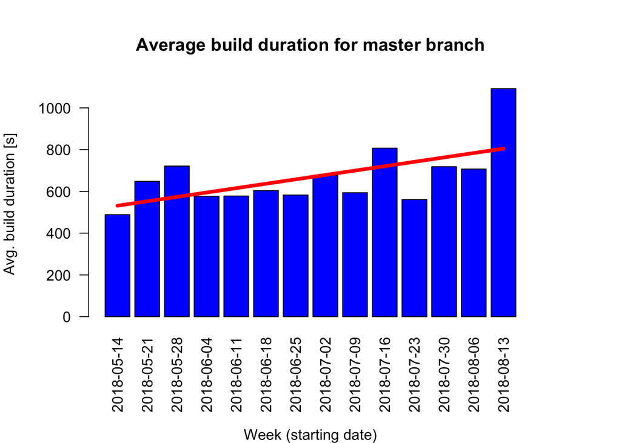

#### Recent slow builds:

[output not shown]

## Broken release branch

### ↘ Downtrend -

### Downtrend: during the last 90 days, the number of broken release builds is decreasing of 75.00%

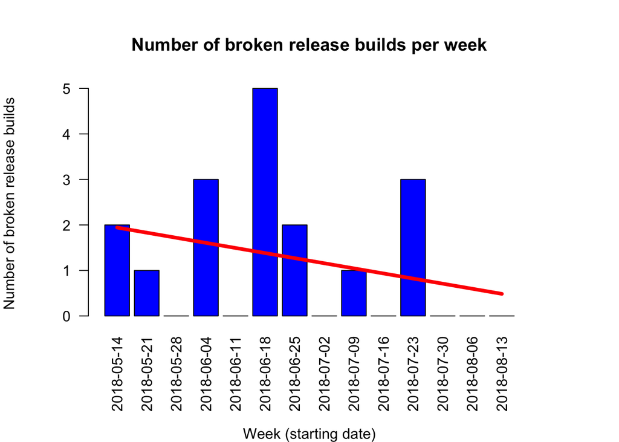

### During the last 90 days your master was broken 17 times, with an average breakage duration of 46905s (~13.03 hours)

## Skip failed tests

### Instead of making a fix when a test failed, we found, over the last 6 months, 2 builds in which at least one test has been skipped/ignored

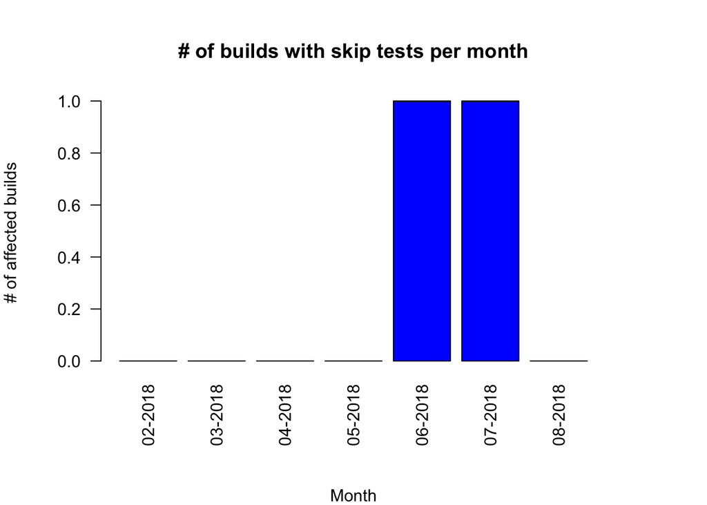

### Skip test has occurred in the following builds:

| Date | Build | SkippedTests |
| --- | --- | --- |
| 2018-07-18 02:02:44 | 405169835 | com.google.javascript.jscomp.IntegrationTest |
| 2018-06-15 23:09:08 | 392935588 | com.google.javascript.jscomp.CompilerTest |

## Aged branches

##### Issues found for branch: closure-compiler-parent-v20180101

- High severity: In your project, branches are typically synced with master every 0s. However, branch closure-compiler-parent-v20180101 has last synced with master on 2018-01-05 02:32:09. and branch master has commits that are 11040917s (~18.26 weeks) newer than that.
- High severity: Your latest commits were performed on branch closure-compiler-parent-v20180805 on 2018-08-09 20:03:29. However, your last changes on branch closure-compiler-parent-v20180101 happened 18725480s (~30.96 weeks) ago, and have not been merged yet. In your project, you typically merge branches within 5597357s (~9.25 weeks).
- High severity: In your project, branches do not deviate for more than 5598706s (~9.26 weeks). However, you are working on branch closure-compiler-parent-v20180101 since 18812318s (~31.11 weeks) without synchronization.
- Medium Severity: You have been working on closure-compiler-parent-v20180101 for 0s.Your feature branches are typically open for 0s.

##### Issues found for branch: closure-compiler-parent-v20180204

- High severity: In your project, branches are typically synced with master every 0s. However, branch closure-compiler-parent-v20180204 has last synced with master on 2018-02-06 00:14:23. and branch master has commits that are 8284383s (~13.7 weeks) newer than that.
- High severity: Your latest commits were performed on branch closure-compiler-parent-v20180805 on 2018-08-09 20:03:29. However, your last changes on branch closure-compiler-parent-v20180204 happened 15968946s (~26.4 weeks) ago, and have not been merged yet. In your project, you typically merge branches within 5597357s (~9.25 weeks).
- High severity: In your project, branches do not deviate for more than 5598706s (~9.26 weeks). However, you are working on branch closure-compiler-parent-v20180204 since 16055784s (~26.55 weeks) without synchronization.
- Medium Severity: You have been working on closure-compiler-parent-v20180204 for 0s.Your feature branches are typically open for 0s.

##### Issues found for branch: closure-compiler-parent-v20180319

- High severity: In your project, branches are typically synced with master every 0s. However, branch closure-compiler-parent-v20180319 has last synced with master on 2018-03-27 21:49:52. and branch master has commits that are 3973054s (~6.57 weeks) newer than that.
- Medium Severity: Your latest commits were performed on branch closure-compiler-parent-v20180805 on 2018-08-09 20:03:29. However, your last changes on branch closure-compiler-parent-v20180319 happened 11657617s (~19.28 weeks) ago, and have not been merged yet. In your project, you typically merge branches within 5597357s (~9.25 weeks).
- Medium Severity: In your project, branches do not deviate for more than 5598706s (~9.26 weeks). However, you are working on branch closure-compiler-parent-v20180319 since 11748055s (~19.42 weeks) without synchronization.
- Medium Severity: You have been working on closure-compiler-parent-v20180319 for 0s.Your feature branches are typically open for 0s.

##### Issues found for branch: closure-compiler-parent-v20180402

- High severity: In your project, branches are typically synced with master every 0s. However, branch closure-compiler-parent-v20180402 has last synced with master on 2018-04-05 17:45:27. and branch master has commits that are 3210119s (~5.31 weeks) newer than that.
- Medium Severity: Your latest commits were performed on branch closure-compiler-parent-v20180805 on 2018-08-09 20:03:29. However, your last changes on branch closure-compiler-parent-v20180402 happened 10894682s (~18.01 weeks) ago, and have not been merged yet. In your project, you typically merge branches within 5597357s (~9.25 weeks).
- Medium Severity: In your project, branches do not deviate for more than 5598706s (~9.26 weeks). However, you are working on branch closure-compiler-parent-v20180402 since 10985120s (~18.16 weeks) without synchronization.
- Medium Severity: You have been working on closure-compiler-parent-v20180402 for 0s.Your feature branches are typically open for 0s.

##### Issues found for branch: closure-compiler-parent-v20180506

- High severity: In your project, branches are typically synced with master every 0s. However, branch closure-compiler-parent-v20180506 has last synced with master on 2018-05-10 01:14:59. and branch master has commits that are 245547s (~2.84 days) newer than that.
- Medium Severity: You have been working on closure-compiler-parent-v20180506 for 0s.Your feature branches are typically open for 0s.

##### Issues found for branch: closure-compiler-parent-v20180610

- Medium Severity: You have been working on closure-compiler-parent-v20180610 for 0s.Your feature branches are typically open for 0s.

##### Issues found for branch: closure-compiler-parent-v20180716

- Medium Severity: You have been working on closure-compiler-parent-v20180716 for 0s.Your feature branches are typically open for 0s.

##### Issues found for branch: closure-compiler-parent-v20180805

- High severity: You have been working on closure-compiler-parent-v20180805 for 8666s (~2.41 hours).Your feature branches are typically open for 0s.

##### Issues found for branch: gwt-beta

- High severity: You have been working on gwt-beta for 37477s (~10.41 hours).Your feature branches are typically open for 0s.

##### Issues found for branch: maven-v20180101

- High severity: In your project, branches are typically synced with master every 0s. However, branch maven-v20180101 has last synced with master on 2018-01-05 02:32:39. and branch master has commits that are 11040887s (~18.26 weeks) newer than that.
- High severity: Your latest commits were performed on branch closure-compiler-parent-v20180805 on 2018-08-09 20:03:29. However, your last changes on branch maven-v20180101 happened 18725450s (~30.96 weeks) ago, and have not been merged yet. In your project, you typically merge branches within 5597357s (~9.25 weeks).
- High severity: In your project, branches do not deviate for more than 5598706s (~9.26 weeks). However, you are working on branch maven-v20180101 since 18812288s (~31.1 weeks) without synchronization.
- Medium Severity: You have been working on maven-v20180101 for 0s.Your feature branches are typically open for 0s.

##### Issues found for branch: maven-v20180204

- High severity: In your project, branches are typically synced with master every 0s. However, branch maven-v20180204 has last synced with master on 2018-02-06 00:14:37. and branch master has commits that are 8284369s (~13.7 weeks) newer than that.
- High severity: Your latest commits were performed on branch closure-compiler-parent-v20180805 on 2018-08-09 20:03:29. However, your last changes on branch maven-v20180204 happened 15968932s (~26.4 weeks) ago, and have not been merged yet. In your project, you typically merge branches within 5597357s (~9.25 weeks).
- High severity: In your project, branches do not deviate for more than 5598706s (~9.26 weeks). However, you are working on branch maven-v20180204 since 16055770s (~26.55 weeks) without synchronization.
- Medium Severity: You have been working on maven-v20180204 for 0s.Your feature branches are typically open for 0s.

##### Issues found for branch: maven-v20180319

- High severity: In your project, branches are typically synced with master every 0s. However, branch maven-v20180319 has last synced with master on 2018-03-27 21:49:57. and branch master has commits that are 3973049s (~6.57 weeks) newer than that.
- Medium Severity: Your latest commits were performed on branch closure-compiler-parent-v20180805 on 2018-08-09 20:03:29. However, your last changes on branch maven-v20180319 happened 11657612s (~19.28 weeks) ago, and have not been merged yet. In your project, you typically merge branches within 5597357s (~9.25 weeks).
- Medium Severity: In your project, branches do not deviate for more than 5598706s (~9.26 weeks). However, you are working on branch maven-v20180319 since 11748050s (~19.42 weeks) without synchronization.
- Medium Severity: You have been working on maven-v20180319 for 0s.Your feature branches are typically open for 0s.

##### Issues found for branch: maven-v20180402

- High severity: In your project, branches are typically synced with master every 0s. However, branch maven-v20180402 has last synced with master on 2018-04-05 17:45:35. and branch master has commits that are 3210111s (~5.31 weeks) newer than that.
- Medium Severity: Your latest commits were performed on branch closure-compiler-parent-v20180805 on 2018-08-09 20:03:29. However, your last changes on branch maven-v20180402 happened 10894674s (~18.01 weeks) ago, and have not been merged yet. In your project, you typically merge branches within 5597357s (~9.25 weeks).
- Medium Severity: In your project, branches do not deviate for more than 5598706s (~9.26 weeks). However, you are working on branch maven-v20180402 since 10985112s (~18.16 weeks) without synchronization.
- Medium Severity: You have been working on maven-v20180402 for 0s.Your feature branches are typically open for 0s.

##### Issues found for branch: maven-v20180506

- High severity: In your project, branches are typically synced with master every 0s. However, branch maven-v20180506 has last synced with master on 2018-05-10 01:15:40. and branch master has commits that are 245506s (~2.84 days) newer than that.
- Medium Severity: You have been working on maven-v20180506 for 0s.Your feature branches are typically open for 0s.

##### Issues found for branch: maven-v20180610

- Medium Severity: You have been working on maven-v20180610 for 0s.Your feature branches are typically open for 0s.

##### Issues found for branch: maven-v20180716

- Medium Severity: You have been working on maven-v20180716 for 0s.Your feature branches are typically open for 0s.

##### Issues found for branch: maven-v20180805

- High severity: You have been working on maven-v20180805 for 8662s (~2.41 hours).Your feature branches are typically open for 0s.

##### Issues found for branch: v20180101

- High severity: In your project, branches are typically synced with master every 0s. However, branch v20180101 has last synced with master on 2018-01-05 02:23:31. and branch master has commits that are 11041435s (~18.26 weeks) newer than that.
- High severity: Your latest commits were performed on branch closure-compiler-parent-v20180805 on 2018-08-09 20:03:29. However, your last changes on branch v20180101 happened 18725998s (~30.96 weeks) ago, and have not been merged yet. In your project, you typically merge branches within 5597357s (~9.25 weeks).
- High severity: In your project, branches do not deviate for more than 5598706s (~9.26 weeks). However, you are working on branch v20180101 since 18812836s (~31.11 weeks) without synchronization.
- Medium Severity: You have been working on v20180101 for 0s.Your feature branches are typically open for 0s.

##### Issues found for branch: v20180204

- High severity: In your project, branches are typically synced with master every 0s. However, branch v20180204 has last synced with master on 2018-02-05 23:52:01. and branch master has commits that are 8285725s (~13.7 weeks) newer than that.
- High severity: Your latest commits were performed on branch closure-compiler-parent-v20180805 on 2018-08-09 20:03:29. However, your last changes on branch v20180204 happened 15970288s (~26.41 weeks) ago, and have not been merged yet. In your project, you typically merge branches within 5597357s (~9.25 weeks).
- High severity: In your project, branches do not deviate for more than 5598706s (~9.26 weeks). However, you are working on branch v20180204 since 16057126s (~26.55 weeks) without synchronization.
- Medium Severity: You have been working on v20180204 for 0s.Your feature branches are typically open for 0s.

##### Issues found for branch: v20180319

- High severity: In your project, branches are typically synced with master every 0s. However, branch v20180319 has last synced with master on 2018-03-23 00:29:39. and branch master has commits that are 4395467s (~7.27 weeks) newer than that.
- Medium Severity: Your latest commits were performed on branch closure-compiler-parent-v20180805 on 2018-08-09 20:03:29. However, your last changes on branch v20180319 happened 12080030s (~19.97 weeks) ago, and have not been merged yet. In your project, you typically merge branches within 5597357s (~9.25 weeks).
- Medium Severity: In your project, branches do not deviate for more than 5598706s (~9.26 weeks). However, you are working on branch v20180319 since 12166868s (~20.12 weeks) without synchronization.
- Medium Severity: You have been working on v20180319 for 0s.Your feature branches are typically open for 0s.

##### Issues found for branch: v20180402

- High severity: In your project, branches are typically synced with master every 0s. However, branch v20180402 has last synced with master on 2018-04-05 17:32:27. and branch master has commits that are 3210899s (~5.31 weeks) newer than that.
- Medium Severity: Your latest commits were performed on branch closure-compiler-parent-v20180805 on 2018-08-09 20:03:29. However, your last changes on branch v20180402 happened 10895462s (~18.01 weeks) ago, and have not been merged yet. In your project, you typically merge branches within 5597357s (~9.25 weeks).
- Medium Severity: In your project, branches do not deviate for more than 5598706s (~9.26 weeks). However, you are working on branch v20180402 since 10985900s (~18.16 weeks) without synchronization.
- Medium Severity: You have been working on v20180402 for 0s.Your feature branches are typically open for 0s.

##### Issues found for branch: v20180506

- High severity: In your project, branches are typically synced with master every 0s. However, branch v20180506 has last synced with master on 2018-05-10 01:02:50. and branch master has commits that are 246276s (~2.85 days) newer than that.
- Medium Severity: You have been working on v20180506 for 0s.Your feature branches are typically open for 0s.

##### Issues found for branch: v20180610

- Medium Severity: You have been working on v20180610 for 0s.Your feature branches are typically open for 0s.

##### Issues found for branch: v20180610-gwt-fix

- Medium Severity: You have been working on v20180610-gwt-fix for 0s.Your feature branches are typically open for 0s.

##### Issues found for branch: v20180716

- Medium Severity: You have been working on v20180716 for 0s.Your feature branches are typically open for 0s.

##### Issues found for branch: v20180805

- Medium Severity: You have been working on v20180805 for 0s.Your feature branches are typically open for 0s.

##### Issues found for branch: webpack-v20180114

- High severity: In your project, branches are typically synced with master every 0s. However, branch webpack-v20180114 has last synced with master on 2018-01-14 21:02:09. and branch master has commits that are 10196717s (~16.86 weeks) newer than that.
- High severity: Your latest commits were performed on branch closure-compiler-parent-v20180805 on 2018-08-09 20:03:29. However, your last changes on branch webpack-v20180114 happened 17881280s (~29.57 weeks) ago, and have not been merged yet. In your project, you typically merge branches within 5597357s (~9.25 weeks).
- High severity: In your project, branches do not deviate for more than 5598706s (~9.26 weeks). However, you are working on branch webpack-v20180114 since 17968118s (~29.71 weeks) without synchronization.
- Medium Severity: You have been working on webpack-v20180114 for 0s.Your feature branches are typically open for 0s.

##### Issues found for branch: webpack-v20180621

- High severity: You have been working on webpack-v20180621 for 1976s (~32.93 minutes).Your feature branches are typically open for 0s.

##### Issues found for branch: webpack-v20180622

- Medium Severity: You have been working on webpack-v20180622 for 0s.Your feature branches are typically open for 0s.

##### Issues found for branch: webpack-v20180623

- High severity: You have been working on webpack-v20180623 for 299s (~4.98 minutes).Your feature branches are typically open for 0s.

##### Issues found for branch: webpack-v20180624

- Medium Severity: You have been working on webpack-v20180624 for 0s.Your feature branches are typically open for 0s.

##### Issues found for branch: webpack-v20180701

- Medium Severity: You have been working on webpack-v20180701 for 0s.Your feature branches are typically open for 0s.

##### Issues found for branch: webpack-v20180702

- Medium Severity: You have been working on webpack-v20180702 for 0s.Your feature branches are typically open for 0s.

##### Tip: Frequently synchronized branches are easier to integrate.

##### Tip: Break features into smaller tasks to finish them faster.